# 2HT Modeling

William Hopper

Oct 07, 2019

# By-Subject Modeling

## Averaged Results

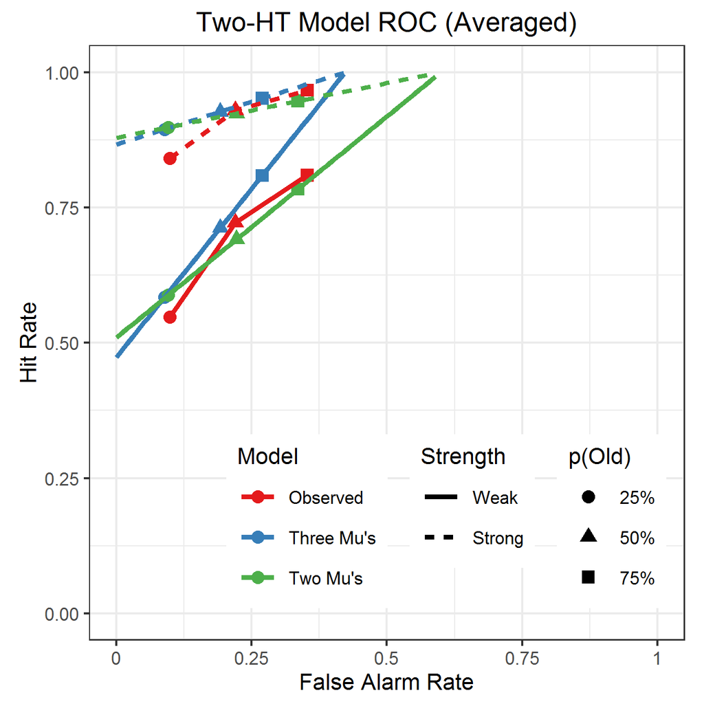

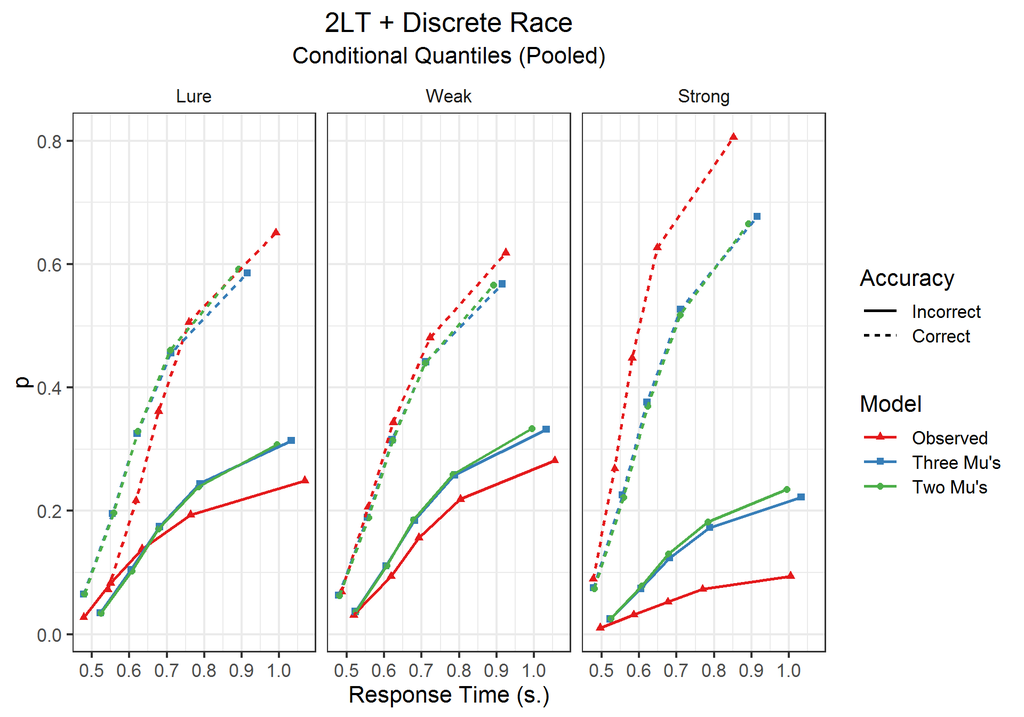

model

Subject

DN<sub>L</sub>

DO<sub>W</sub>

DO<sub>S</sub>

GO

GO<sub>C</sub>

GO<sub>N</sub>

GO<sub>L</sub>

µ<sub>D</sub>

µ<sub>G</sub>

µ<sub>DN</sub>

σ

v

G<sup>2</sup>

yoked

101

0.195

0.518

0.892

0.410

0.125

0.258

0.497

0.453

0.503

0.070

0.173

159.915

102

0.417

0.152

0.603

0.695

0.432

0.665

0.758

0.632

0.519

0.081

0.320

130.064

103

0.368

0.635

0.927

0.491

0.173

0.406

0.773

0.477

0.504

0.065

0.101

197.737

104

0.569

0.586

0.893

0.322

0.095

0.320

0.546

0.490

0.566

0.029

0.500

292.017

105

0.253

0.010

0.657

0.836

0.140

0.890

0.975

0.546

0.371

0.080

0.171

140.245

106

0.527

0.554

0.944

0.430

0.218

0.384

0.516

0.499

0.534

0.102

0.327

252.844

107

0.500

0.477

0.853

0.362

0.105

0.421

0.680

0.578

0.678

0.088

0.233

109.501

108

0.808

0.784

0.997

0.330

0.129

0.222

0.574

0.475

0.528

0.048

0.175

306.306

109

0.208

0.829

0.989

0.146

0.059

0.069

0.151

0.469

0.593

0.044

0.170

361.395

110

0.688

0.251

0.871

0.528

0.235

0.462

0.550

0.532

0.489

0.086

0.163

136.847

111

0.010

0.582

0.942

0.300

0.078

0.173

0.450

0.476

0.548

0.046

0.125

249.560

112

0.115

0.597

0.952

0.444

0.259

0.282

0.322

0.525

0.622

0.070

0.260

220.967

113

0.829

0.702

0.994

0.233

0.093

0.376

0.399

0.578

0.655

0.052

0.246

283.323

114

0.116

0.455

0.793

0.433

0.104

0.262

0.638

0.459

0.508

0.099

0.178

179.915

unyoked

101

0.561

0.415

0.864

0.470

0.221

0.453

0.646

0.434

0.484

0.562

0.063

0.202

113.119

102

0.397

0.268

0.618

0.659

0.404

0.635

0.733

0.517

0.533

0.699

0.078

0.318

101.744

103

0.544

0.565

0.909

0.514

0.238

0.538

0.843

0.453

0.490

0.529

0.058

0.119

159.846

104

0.642

0.542

0.880

0.345

0.116

0.381

0.612

0.479

0.557

0.545

0.024

0.500

274.948

105

0.248

0.039

0.632

0.826

0.137

0.887

0.975

0.430

0.379

0.567

0.085

0.170

132.053

106

0.608

0.513

0.939

0.434

0.261

0.446

0.563

0.460

0.518

0.574

0.090

0.346

220.371

107

0.588

0.430

0.836

0.383

0.129

0.480

0.725

0.552

0.668

0.626

0.084

0.246

91.481

108

0.823

0.777

0.997

0.333

0.140

0.244

0.594

0.471

0.527

0.482

0.048

0.176

304.355

109

0.532

0.817

0.989

0.187

0.099

0.113

0.243

0.466

0.619

0.544

0.055

0.171

341.167

110

0.710

0.261

0.856

0.484

0.247

0.473

0.556

0.468

0.490

0.583

0.079

0.163

93.108

111

0.572

0.495

0.929

0.381

0.176

0.368

0.677

0.466

0.525

0.625

0.033

0.161

206.023

112

0.588

0.453

0.933

0.552

0.520

0.525

0.560

0.506

0.589

0.688

0.056

0.318

168.981

113

0.857

0.682

0.993

0.243

0.111

0.432

0.438

0.566

0.650

0.595

0.052

0.251

273.141

114

0.408

0.371

0.756

0.476

0.152

0.380

0.761

0.439

0.495

0.595

0.095

0.200

152.242

## Individual Subjects

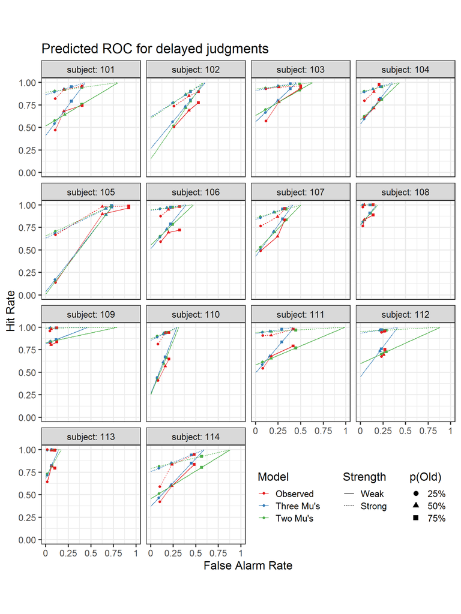

### Subject 101

model

Subject

DN<sub>L</sub>

DO<sub>W</sub>

DO<sub>S</sub>

GO

GO<sub>C</sub>

GO<sub>N</sub>

GO<sub>L</sub>

µ<sub>D</sub>

µ<sub>G</sub>

µ<sub>DN</sub>

s

v

yoked

101

0.195

0.518

0.892

0.41

0.125

0.258

0.497

0.453

0.503

0.070

0.173

unyoked

101

0.561

0.415

0.864

0.47

0.221

0.453

0.646

0.434

0.484

0.562

0.063

0.202

| Subject | model | LL | G<sup>2</sup> | df | p(X<sup>2</sup>) | fevals | gevals | niter | convcode |
| --- | --- | --- | --- | --- | --- | --- | --- | --- | --- |
| 101 | yoked | -180.287 | 159.915 | 31 | 0 | 104 | 1119 | 78 | 0 |
| 101 | unyoked | -156.889 | 113.119 | 30 | 0 | 107 | 1344 | 91 | 0 |

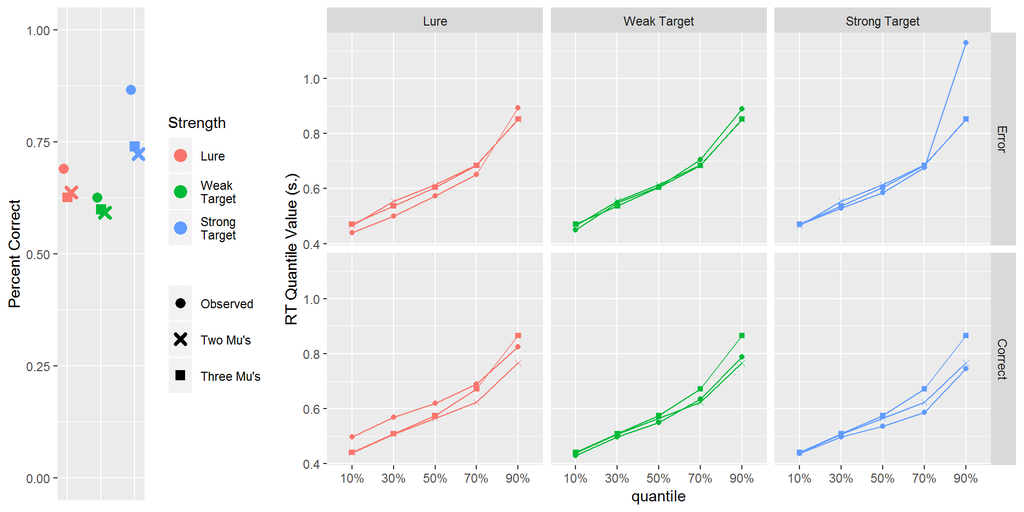

### Subject 102

model

Subject

DN<sub>L</sub>

DO<sub>W</sub>

DO<sub>S</sub>

GO

GO<sub>C</sub>

GO<sub>N</sub>

GO<sub>L</sub>

µ<sub>D</sub>

µ<sub>G</sub>

µ<sub>DN</sub>

s

v

yoked

102

0.417

0.152

0.603

0.695

0.432

0.665

0.758

0.632

0.519

0.081

0.320

unyoked

102

0.397

0.268

0.618

0.659

0.404

0.635

0.733

0.517

0.533

0.699

0.078

0.318

| Subject | model | LL | G<sup>2</sup> | df | p(X<sup>2</sup>) | fevals | gevals | niter | convcode |
| --- | --- | --- | --- | --- | --- | --- | --- | --- | --- |
| 102 | yoked | -165.461 | 130.064 | 31 | 0 | 106 | 978 | 78 | 0 |
| 102 | unyoked | -151.301 | 101.744 | 30 | 0 | 116 | 1326 | 88 | 0 |

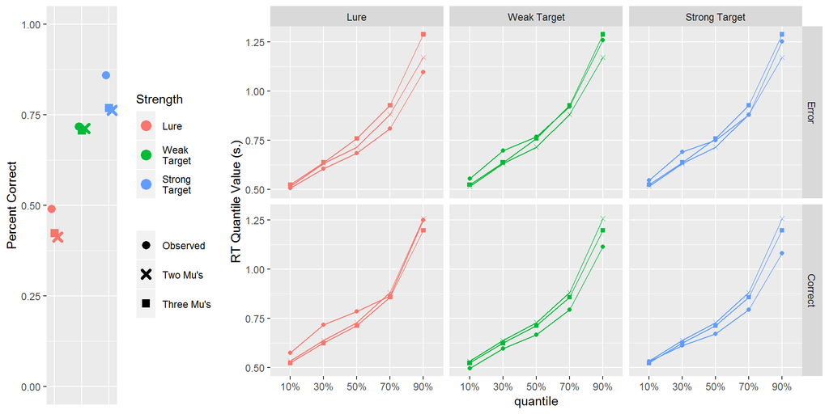

### Subject 103

model

Subject

DN<sub>L</sub>

DO<sub>W</sub>

DO<sub>S</sub>

GO

GO<sub>C</sub>

GO<sub>N</sub>

GO<sub>L</sub>

µ<sub>D</sub>

µ<sub>G</sub>

µ<sub>DN</sub>

s

v

yoked

103

0.368

0.635

0.927

0.491

0.173

0.406

0.773

0.477

0.504

0.065

0.101

unyoked

103

0.544

0.565

0.909

0.514

0.238

0.538

0.843

0.453

0.490

0.529

0.058

0.119

| Subject | model | LL | G<sup>2</sup> | df | p(X<sup>2</sup>) | fevals | gevals | niter | convcode |
| --- | --- | --- | --- | --- | --- | --- | --- | --- | --- |
| 103 | yoked | -196.397 | 197.737 | 31 | 0 | 132 | 1409 | 106 | 0 |
| 103 | unyoked | -177.451 | 159.846 | 30 | 0 | 169 | 1744 | 128 | 0 |

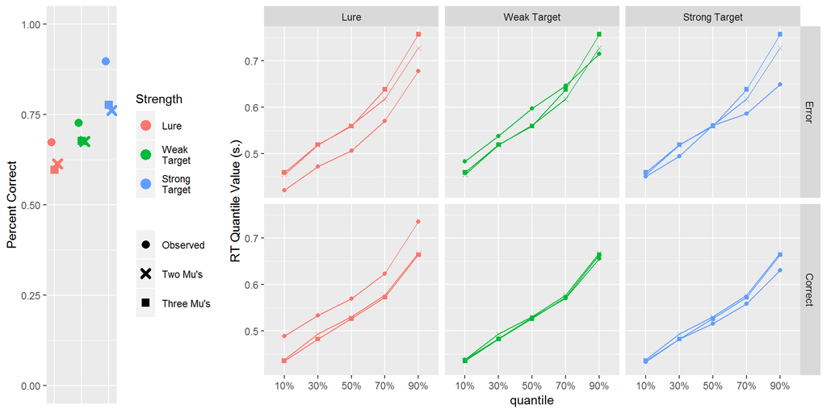

### Subject 104

model

Subject

DN<sub>L</sub>

DO<sub>W</sub>

DO<sub>S</sub>

GO

GO<sub>C</sub>

GO<sub>N</sub>

GO<sub>L</sub>

µ<sub>D</sub>

µ<sub>G</sub>

µ<sub>DN</sub>

s

v

yoked

104

0.569

0.586

0.893

0.322

0.095

0.320

0.546

0.490

0.566

0.029

0.5

unyoked

104

0.642

0.542

0.880

0.345

0.116

0.381

0.612

0.479

0.557

0.545

0.024

0.5

| Subject | model | LL | G<sup>2</sup> | df | p(X<sup>2</sup>) | fevals | gevals | niter | convcode |
| --- | --- | --- | --- | --- | --- | --- | --- | --- | --- |
| 104 | yoked | -243.559 | 292.017 | 31 | 0 | 89 | 1011 | 74 | 0 |
| 104 | unyoked | -235.025 | 274.948 | 30 | 0 | 85 | 1094 | 68 | 0 |

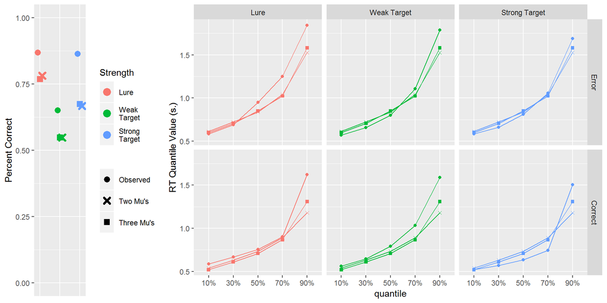

### Subject 105

model

Subject

DN<sub>L</sub>

DO<sub>W</sub>

DO<sub>S</sub>

GO

GO<sub>C</sub>

GO<sub>N</sub>

GO<sub>L</sub>

µ<sub>D</sub>

µ<sub>G</sub>

µ<sub>DN</sub>

s

v

yoked

105

0.253

0.010

0.657

0.836

0.140

0.890

0.975

0.546

0.371

0.080

0.171

unyoked

105

0.248

0.039

0.632

0.826

0.137

0.887

0.975

0.430

0.379

0.567

0.085

0.170

| Subject | model | LL | G<sup>2</sup> | df | p(X<sup>2</sup>) | fevals | gevals | niter | convcode |
| --- | --- | --- | --- | --- | --- | --- | --- | --- | --- |
| 105 | yoked | -163.893 | 140.245 | 31 | 0 | 165 | 1544 | 124 | 0 |
| 105 | unyoked | -159.797 | 132.053 | 30 | 0 | 155 | 1604 | 120 | 0 |

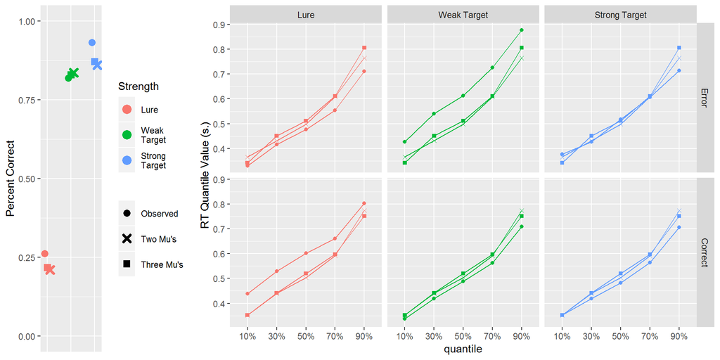

### Subject 106

model

Subject

DN<sub>L</sub>

DO<sub>W</sub>

DO<sub>S</sub>

GO

GO<sub>C</sub>

GO<sub>N</sub>

GO<sub>L</sub>

µ<sub>D</sub>

µ<sub>G</sub>

µ<sub>DN</sub>

s

v

yoked

106

0.527

0.554

0.944

0.430

0.218

0.384

0.516

0.499

0.534

0.102

0.327

unyoked

106

0.608

0.513

0.939

0.434

0.261

0.446

0.563

0.460

0.518

0.574

0.090

0.346

| Subject | model | LL | G<sup>2</sup> | df | p(X<sup>2</sup>) | fevals | gevals | niter | convcode |
| --- | --- | --- | --- | --- | --- | --- | --- | --- | --- |
| 106 | yoked | -224.821 | 252.844 | 31 | 0 | 118 | 1291 | 92 | 0 |
| 106 | unyoked | -208.585 | 220.371 | 30 | 0 | 115 | 1433 | 91 | 0 |

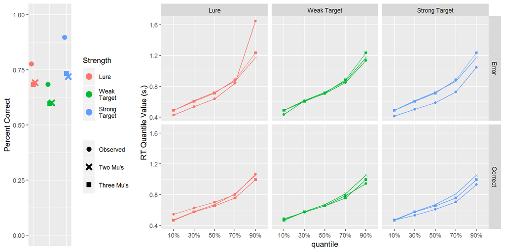

### Subject 107

model

Subject

DN<sub>L</sub>

DO<sub>W</sub>

DO<sub>S</sub>

GO

GO<sub>C</sub>

GO<sub>N</sub>

GO<sub>L</sub>

µ<sub>D</sub>

µ<sub>G</sub>

µ<sub>DN</sub>

s

v

yoked

107

0.500

0.477

0.853

0.362

0.105

0.421

0.680

0.578

0.678

0.088

0.233

unyoked

107

0.588

0.430

0.836

0.383

0.129

0.480

0.725

0.552

0.668

0.626

0.084

0.246

| Subject | model | LL | G<sup>2</sup> | df | p(X<sup>2</sup>) | fevals | gevals | niter | convcode |
| --- | --- | --- | --- | --- | --- | --- | --- | --- | --- |
| 107 | yoked | -154.076 | 109.501 | 31 | 0 | 100 | 1229 | 79 | 0 |
| 107 | unyoked | -145.066 | 91.481 | 30 | 0 | 136 | 1670 | 103 | 0 |

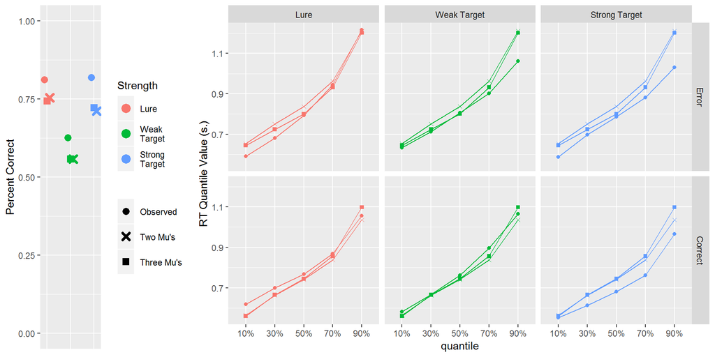

### Subject 108

model

Subject

DN<sub>L</sub>

DO<sub>W</sub>

DO<sub>S</sub>

GO

GO<sub>C</sub>

GO<sub>N</sub>

GO<sub>L</sub>

µ<sub>D</sub>

µ<sub>G</sub>

µ<sub>DN</sub>

s

v

yoked

108

0.808

0.784

0.997

0.330

0.129

0.222

0.574

0.475

0.528

0.048

0.175

unyoked

108

0.823

0.777

0.997

0.333

0.140

0.244

0.594

0.471

0.527

0.482

0.048

0.176

| Subject | model | LL | G<sup>2</sup> | df | p(X<sup>2</sup>) | fevals | gevals | niter | convcode |
| --- | --- | --- | --- | --- | --- | --- | --- | --- | --- |
| 108 | yoked | -239.333 | 306.306 | 31 | 0 | 138 | 1191 | 94 | 0 |
| 108 | unyoked | -238.357 | 304.355 | 30 | 0 | 140 | 1471 | 102 | 0 |

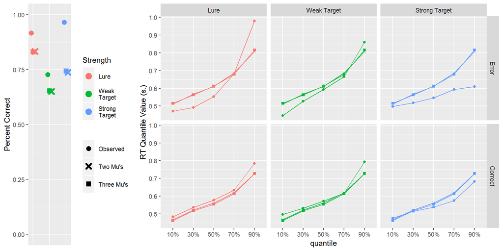

### Subject 109

model

Subject

DN<sub>L</sub>

DO<sub>W</sub>

DO<sub>S</sub>

GO

GO<sub>C</sub>

GO<sub>N</sub>

GO<sub>L</sub>

µ<sub>D</sub>

µ<sub>G</sub>

µ<sub>DN</sub>

s

v

yoked

109

0.208

0.829

0.989

0.146

0.059

0.069

0.151

0.469

0.593

0.044

0.170

unyoked

109

0.532

0.817

0.989

0.187

0.099

0.113

0.243

0.466

0.619

0.544

0.055

0.171

| Subject | model | LL | G<sup>2</sup> | df | p(X<sup>2</sup>) | fevals | gevals | niter | convcode |
| --- | --- | --- | --- | --- | --- | --- | --- | --- | --- |
| 109 | yoked | -265.258 | 361.395 | 31 | 0 | 149 | 1530 | 118 | 0 |
| 109 | unyoked | -255.144 | 341.167 | 30 | 0 | 144 | 1497 | 110 | 0 |

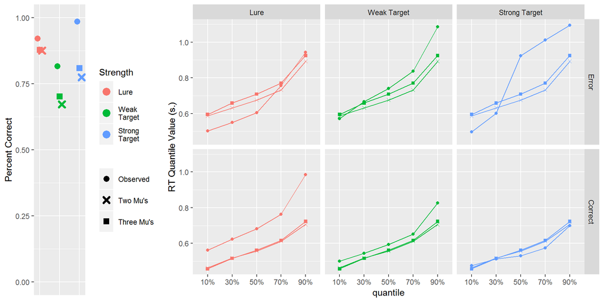

### Subject 110

model

Subject

DN<sub>L</sub>

DO<sub>W</sub>

DO<sub>S</sub>

GO

GO<sub>C</sub>

GO<sub>N</sub>

GO<sub>L</sub>

µ<sub>D</sub>

µ<sub>G</sub>

µ<sub>DN</sub>

s

v

yoked

110

0.688

0.251

0.871

0.528

0.235

0.462

0.550

0.532

0.489

0.086

0.163

unyoked

110

0.710

0.261

0.856

0.484

0.247

0.473

0.556

0.468

0.490

0.583

0.079

0.163

| Subject | model | LL | G<sup>2</sup> | df | p(X<sup>2</sup>) | fevals | gevals | niter | convcode |
| --- | --- | --- | --- | --- | --- | --- | --- | --- | --- |
| 110 | yoked | -169.746 | 136.847 | 31 | 0 | 104 | 1094 | 78 | 0 |
| 110 | unyoked | -147.877 | 93.108 | 30 | 0 | 130 | 1359 | 99 | 0 |

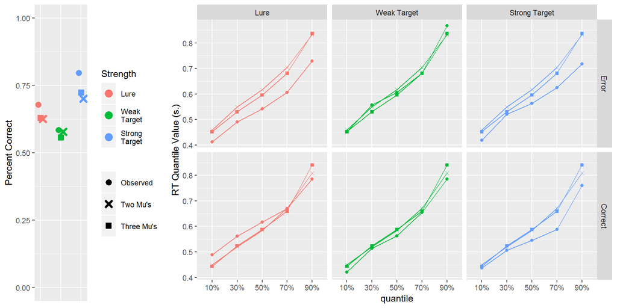

### Subject 111

model

Subject

DN<sub>L</sub>

DO<sub>W</sub>

DO<sub>S</sub>

GO

GO<sub>C</sub>

GO<sub>N</sub>

GO<sub>L</sub>

µ<sub>D</sub>

µ<sub>G</sub>

µ<sub>DN</sub>

s

v

yoked

111

0.010

0.582

0.942

0.300

0.078

0.173

0.450

0.476

0.548

0.046

0.125

unyoked

111

0.572

0.495

0.929

0.381

0.176

0.368

0.677

0.466

0.525

0.625

0.033

0.161

| Subject | model | LL | G<sup>2</sup> | df | p(X<sup>2</sup>) | fevals | gevals | niter | convcode |
| --- | --- | --- | --- | --- | --- | --- | --- | --- | --- |
| 111 | yoked | -222.632 | 249.560 | 31 | 0 | 138 | 1247 | 97 | 0 |
| 111 | unyoked | -200.864 | 206.023 | 30 | 0 | 135 | 1475 | 106 | 0 |

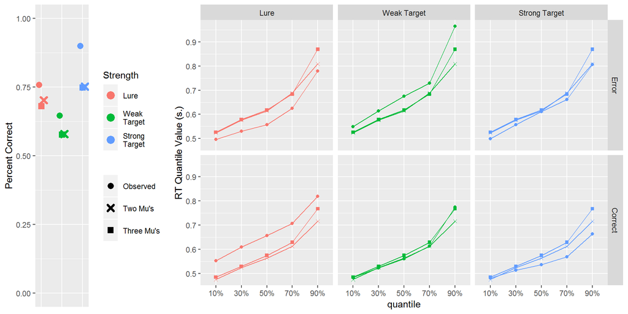

### Subject 112

model

Subject

DN<sub>L</sub>

DO<sub>W</sub>

DO<sub>S</sub>

GO

GO<sub>C</sub>

GO<sub>N</sub>

GO<sub>L</sub>

µ<sub>D</sub>

µ<sub>G</sub>

µ<sub>DN</sub>

s

v

yoked

112

0.115

0.597

0.952

0.444

0.259

0.282

0.322

0.525

0.622

0.070

0.260

unyoked

112

0.588

0.453

0.933

0.552

0.520

0.525

0.560

0.506

0.589

0.688

0.056

0.318

| Subject | model | LL | G<sup>2</sup> | df | p(X<sup>2</sup>) | fevals | gevals | niter | convcode |
| --- | --- | --- | --- | --- | --- | --- | --- | --- | --- |
| 112 | yoked | -205.431 | 220.967 | 31 | 0 | 115 | 1433 | 90 | 0 |
| 112 | unyoked | -179.438 | 168.981 | 30 | 0 | 124 | 1357 | 90 | 0 |

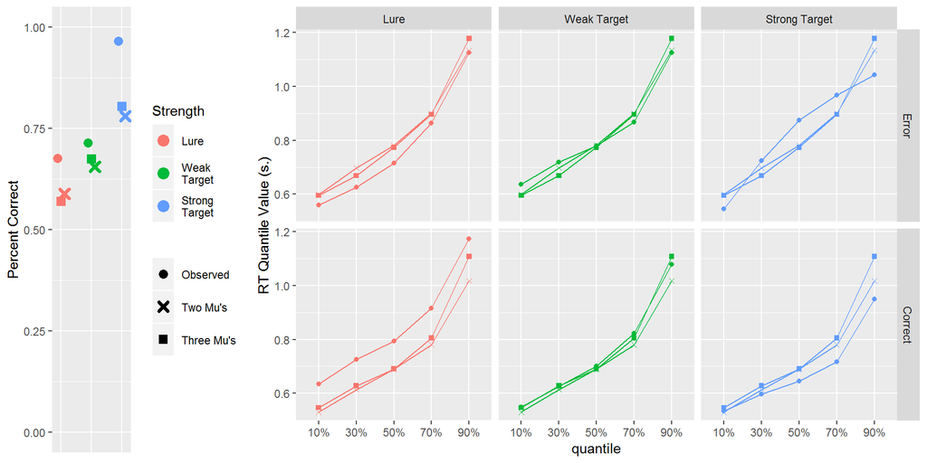

### Subject 113

model

Subject

DN<sub>L</sub>

DO<sub>W</sub>

DO<sub>S</sub>

GO

GO<sub>C</sub>

GO<sub>N</sub>

GO<sub>L</sub>

µ<sub>D</sub>

µ<sub>G</sub>

µ<sub>DN</sub>

s

v

yoked

113

0.829

0.702

0.994

0.233

0.093

0.376

0.399

0.578

0.655

0.052

0.246

unyoked

113

0.857

0.682

0.993

0.243

0.111

0.432

0.438

0.566

0.650

0.595

0.052

0.251

| Subject | model | LL | G<sup>2</sup> | df | p(X<sup>2</sup>) | fevals | gevals | niter | convcode |
| --- | --- | --- | --- | --- | --- | --- | --- | --- | --- |
| 113 | yoked | -229.198 | 283.323 | 31 | 0 | 133 | 1330 | 105 | 0 |
| 113 | unyoked | -224.107 | 273.141 | 30 | 0 | 136 | 1525 | 104 | 0 |

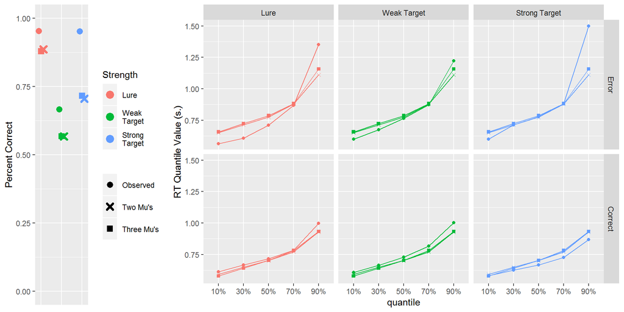

### Subject 114

model

Subject

DN<sub>L</sub>

DO<sub>W</sub>

DO<sub>S</sub>

GO

GO<sub>C</sub>

GO<sub>N</sub>

GO<sub>L</sub>

µ<sub>D</sub>

µ<sub>G</sub>

µ<sub>DN</sub>

s

v

yoked

114

0.116

0.455

0.793

0.433

0.104

0.262

0.638

0.459

0.508

0.099

0.178

unyoked

114

0.408

0.371

0.756

0.476

0.152

0.380

0.761

0.439

0.495

0.595

0.095

0.200

| Subject | model | LL | G<sup>2</sup> | df | p(X<sup>2</sup>) | fevals | gevals | niter | convcode |
| --- | --- | --- | --- | --- | --- | --- | --- | --- | --- |
| 114 | yoked | -191.737 | 179.915 | 31 | 0 | 104 | 1088 | 80 | 0 |
| 114 | unyoked | -177.901 | 152.242 | 30 | 0 | 116 | 1617 | 91 | 0 |

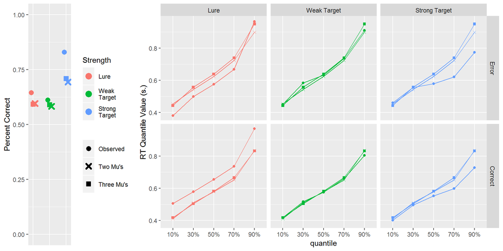

## Parameter Comparison

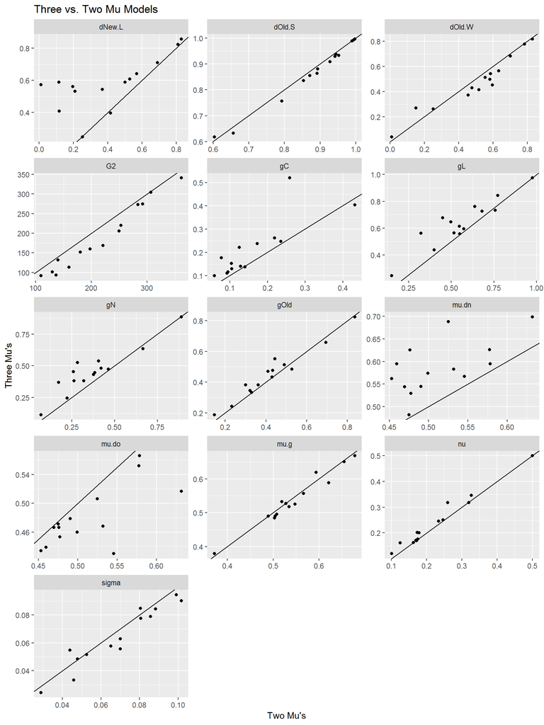

# Aggregated Modeling

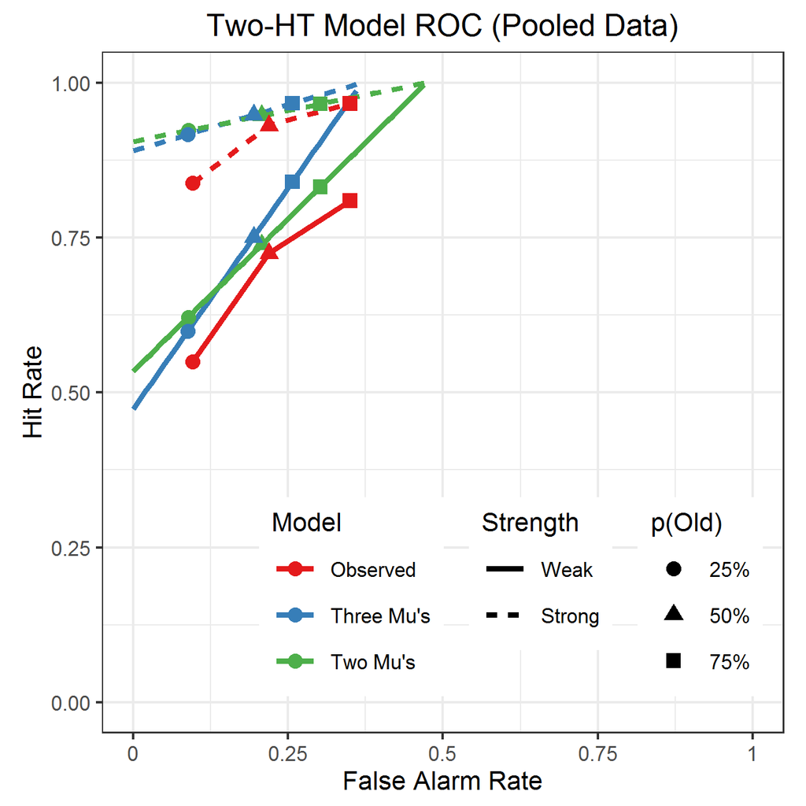

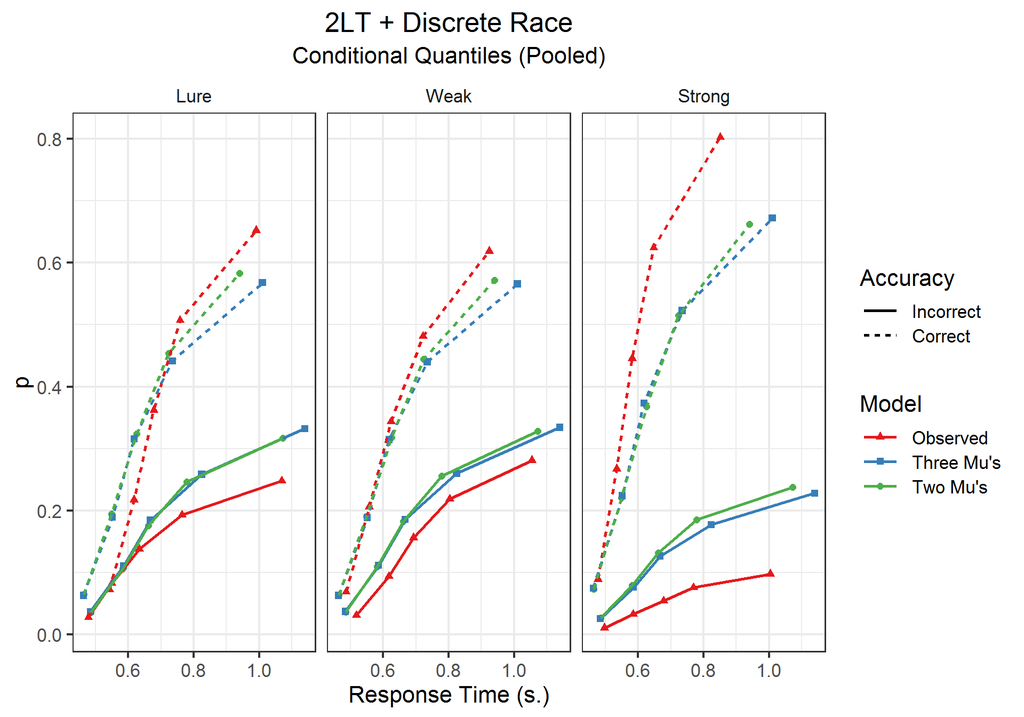

model

DN<sub>L</sub>

DO<sub>W</sub>

DO<sub>S</sub>

GO

GO<sub>C</sub>

GO<sub>N</sub>

GO<sub>L</sub>

µ<sub>D</sub>

µ<sub>G</sub>

µ<sub>DN</sub>

σ

v

yoked

0.527

0.534

0.905

0.490

0.188

0.439

0.639

0.486

0.511

0.082

0.277

unyoked

0.631

0.473

0.890

0.495

0.239

0.527

0.696

0.449

0.495

0.57

0.069

0.293

| model | LL | G<sup>2</sup> | df | p(X<sup>2</sup>) | fevals | gevals | niter | convcode |
| --- | --- | --- | --- | --- | --- | --- | --- | --- |
| yoked | -1412.676 | 2516.589 | 31 | 0 | 142 | 1825 | 111 | 0 |
| unyoked | -1106.699 | 1904.634 | 30 | 0 | 142 | 1990 | 118 | 0 |